# Chapter 2: Regression and model validation excercise

*On tuesday, I did the data wrangling excercises and on wednesday, the data analysis tasks. I have some prior experience in working with dplyr, so the wrangling part was not too challenging, but it was great refreshment. For example, I realised that in dplyr, it’s not too easy to calculate “rowMeans” -style of functions selecting only a part of the file - the best way to do it was by first selecting a part of dataset.*

### Here begins the code

setup, setting the working directory and opening the data

```r
 ## change the working directory of this r markdown file
knitr::opts_chunk$set(root.dir = "/Users/pecsi_max/Desktop/GitHub/IODS-project/data/")
setwd("/Users/pecsi_max/Desktop/GitHub/IODS-project/data/")
getwd()

#load the required packages
library(ggplot2)
library(GGally)
library(dplyr)
```

Opening the data *“tbl_df” converts the data frame to a “data table” -format. To my knowledge, it is recommended when using dplyr, although I believe that in these excercises it’s not a big difference.*

```r
#read the data.

learn <- tbl_df(read.csv("/Users/pecsi_max/Desktop/GitHub/IODS-project/data/learning2014.csv"))

#structure of data
str(learn)
```

```
## Classes 'tbl_df', 'tbl' and 'data.frame':    166 obs. of  7 variables:
##  $ gender  : Factor w/ 2 levels "F","M": 1 2 1 2 2 1 2 1 2 1 ...
##  $ age     : int  53 55 49 53 49 38 50 37 37 42 ...
##  $ attitude: int  37 31 25 35 37 38 35 29 38 21 ...
##  $ deep    : num  3.58 2.92 3.5 3.5 3.67 ...
##  $ surf    : num  2.58 3.17 2.25 2.25 2.83 ...
##  $ stra    : num  3.38 2.75 3.62 3.12 3.62 ...
##  $ points  : int  25 12 24 10 22 21 21 31 24 26 ...
```

```r
#dimensions of data
dim(learn)
```

```
## [1] 166   7
```

#### About the data

“learn” is a dataset of 166 students, with variables “gender”, “age”, “attitude”, “points”, depe, stra, surf. Last three are scales measuring different aspects of learning (deep, strategic or surface learning). The students scoring 0 points on exam are not included.

#### Exploring the data

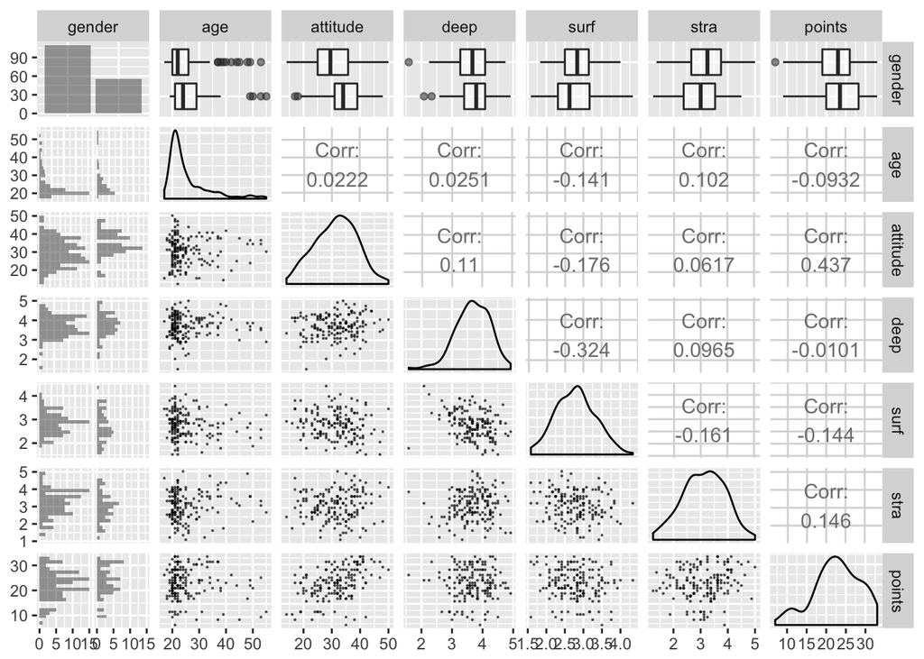

```r
#create a plot matrix with all the variables
pairs_plot <- ggpairs(learn, mapping = aes(alpha = 0.5),
                      lower = list(combo = wrap("facethist", bins = 20),
                                   continuous = wrap("points", size=0.1)),
                      upper = list(continuous = wrap("cor", alpha = 1)))
pairs_plot
```

#### Comments on preliminary associations

##### Different aspects of learning and points

- Strategic learning slightly positively correlated with poits
- Deep learning not correlated with points
- Surface learning negatively correlated with points
- Correlations of attitude and these aspects of learning are similar

### Linear regression model

#### Model 1

```r
#construct a model, choosing 3 variables as dependent vars: attitude, surface learning, strategic learning
model1 <- lm(points ~ attitude + stra + surf, data = learn)
summary(model1)
```

```
##
## Call:
## lm(formula = points ~ attitude + stra + surf, data = learn)
##
## Residuals:
##      Min       1Q   Median       3Q      Max
## -17.1550  -3.4346   0.5156   3.6401  10.8952
##
## Coefficients:
##             Estimate Std. Error t value Pr(>|t|)
## (Intercept) 11.01711    3.68375   2.991  0.00322 **
## attitude     0.33952    0.05741   5.913 1.93e-08 ***
## stra         0.85313    0.54159   1.575  0.11716
## surf        -0.58607    0.80138  -0.731  0.46563
## ---
## Signif. codes:  0 '***' 0.001 '**' 0.01 '*' 0.05 '.' 0.1 ' ' 1
##
## Residual standard error: 5.296 on 162 degrees of freedom
## Multiple R-squared:  0.2074, Adjusted R-squared:  0.1927
## F-statistic: 14.13 on 3 and 162 DF,  p-value: 3.156e-08
```

##### Comments on model 1

There is statistically significant linear association, adj. R-squared = 0.192. Only attitude appears to be statistically significantly associated with exam points. Let’s change the model…

#### Model 2

```r
# testing to put all variables in the model
model_all <- lm(points ~ attitude + gender + age + deep + stra + surf, data = learn)
summary(model_all)
```

```
##
## Call:
## lm(formula = points ~ attitude + gender + age + deep + stra +
##     surf, data = learn)
##
## Residuals:
##      Min       1Q   Median       3Q      Max
## -17.4506  -3.2479   0.3879   3.5243  11.4820
##
## Coefficients:
##             Estimate Std. Error t value Pr(>|t|)
## (Intercept) 18.30246    5.25723   3.481 0.000644 ***
## attitude     0.34430    0.05978   5.760 4.24e-08 ***
## genderM     -0.05858    0.92985  -0.063 0.949845
## age         -0.09607    0.05396  -1.780 0.076929 .
## deep        -1.04279    0.78438  -1.329 0.185606
## stra         0.95871    0.55150   1.738 0.084083 .
## surf        -1.10891    0.84467  -1.313 0.191132
## ---
## Signif. codes:  0 '***' 0.001 '**' 0.01 '*' 0.05 '.' 0.1 ' ' 1
##
## Residual standard error: 5.265 on 159 degrees of freedom
## Multiple R-squared:  0.2312, Adjusted R-squared:  0.2021
## F-statistic: 7.967 on 6 and 159 DF,  p-value: 1.599e-07
```

Age and stra are perhaps the best predictors in addition to attitude, even though their p>0.05

#### Final model

Create a model with three best explaining variables

```r
model_final <- lm(points ~ attitude + age + stra, data = learn)
summary(model_final)
```

```
##
## Call:
## lm(formula = points ~ attitude + age + stra, data = learn)
##
## Residuals:
##      Min       1Q   Median       3Q      Max
## -18.1149  -3.2003   0.3303   3.4129  10.7599
##
## Coefficients:
##             Estimate Std. Error t value Pr(>|t|)
## (Intercept) 10.89543    2.64834   4.114 6.17e-05 ***
## attitude     0.34808    0.05622   6.191 4.72e-09 ***
## age         -0.08822    0.05302  -1.664   0.0981 .
## stra         1.00371    0.53434   1.878   0.0621 .
## ---
## Signif. codes:  0 '***' 0.001 '**' 0.01 '*' 0.05 '.' 0.1 ' ' 1
##
## Residual standard error: 5.26 on 162 degrees of freedom
## Multiple R-squared:  0.2182, Adjusted R-squared:  0.2037
## F-statistic: 15.07 on 3 and 162 DF,  p-value: 1.07e-08
```

##### Comments on the final model

Adjusted R-squared = 0.2037, marginally better than in model 1. Adjusted R-squared of 0.2037 means that the model explains 20.4% in variance observed in exam points. The “adjusted” word means that the value is adjusted for the number of variables in the model.

Only attitude is statistically significantly associated with points; an increase of 1 in attitude brings 0.34 points in exam. 1 year increase in age takes 0.09 points in exam, but the relationship is not considered statistically significant. Strategic learning is “borderline significant”, associating perhaps to slightly better points. However, it should be stressed that attitude is the only variable clearly associated with exam scores.

### Visualization of the model diagnostics

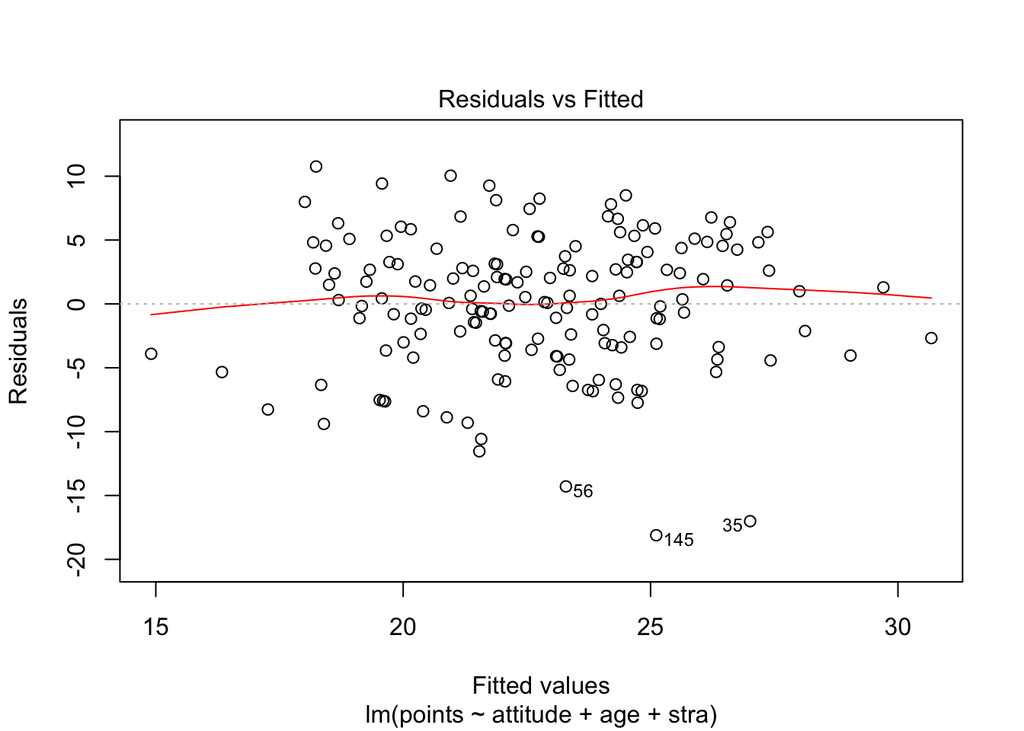

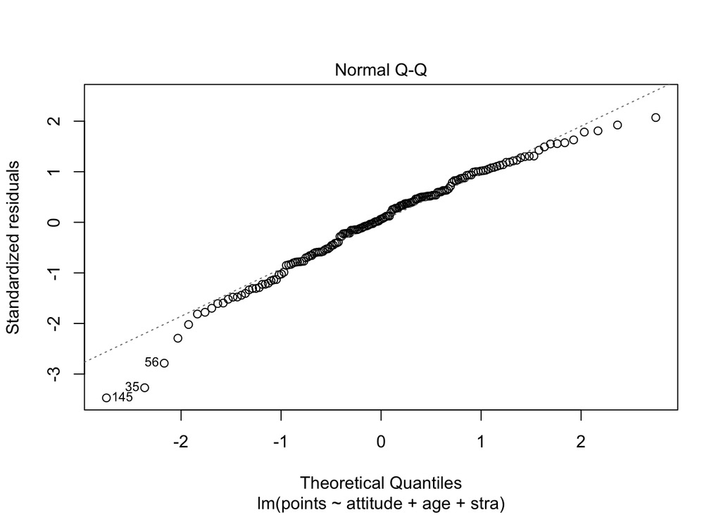

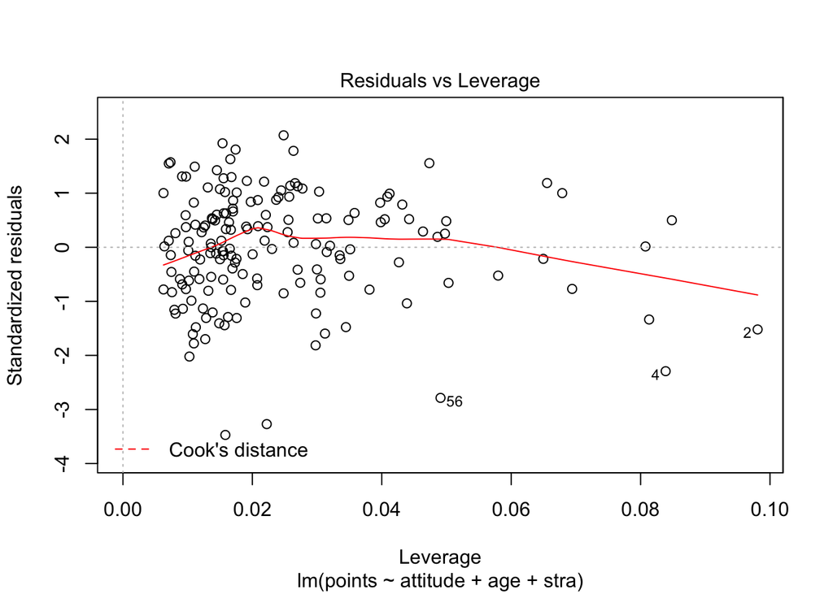

```r
plot(model_final, which = (c(1, 2, 5)))
```